# Lab 2 Data Visualization

Author

Dylan Mackler

# Example 1.2.2

```r
library(tidyverse)
library(palmerpenguins)
library(ggthemes)
```

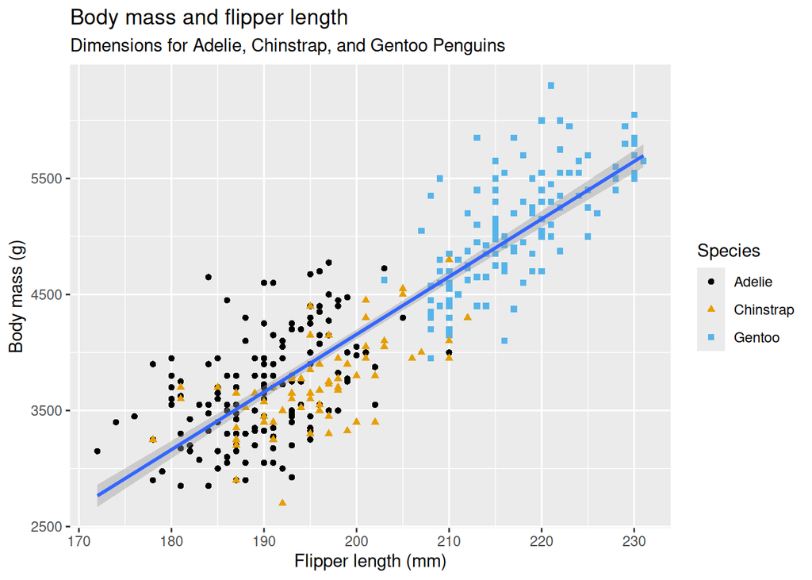

```r
ggplot(
  data = penguins,
  mapping = aes(x = flipper_length_mm, y = body_mass_g)
) +
  geom_point(aes(color = species, shape = species)) +
  geom_smooth(method = "lm") +
  labs(
    title = "Body mass and flipper length",
    subtitle = "Dimensions for Adelie, Chinstrap, and Gentoo Penguins",
    x = "Flipper length (mm)", y = "Body mass (g)",
    color = "Species", shape = "Species"
  ) +
  scale_color_colorblind()
```

## 1.2.5 Exercise

### 1.

```r
library(palmerpenguins)

dim(penguins)
```

```
[1] 344   8
```

### 2.

```r
?(penguins)
```

The vertical thickness of the penguin’s bill, measured in millimeters

### 3.

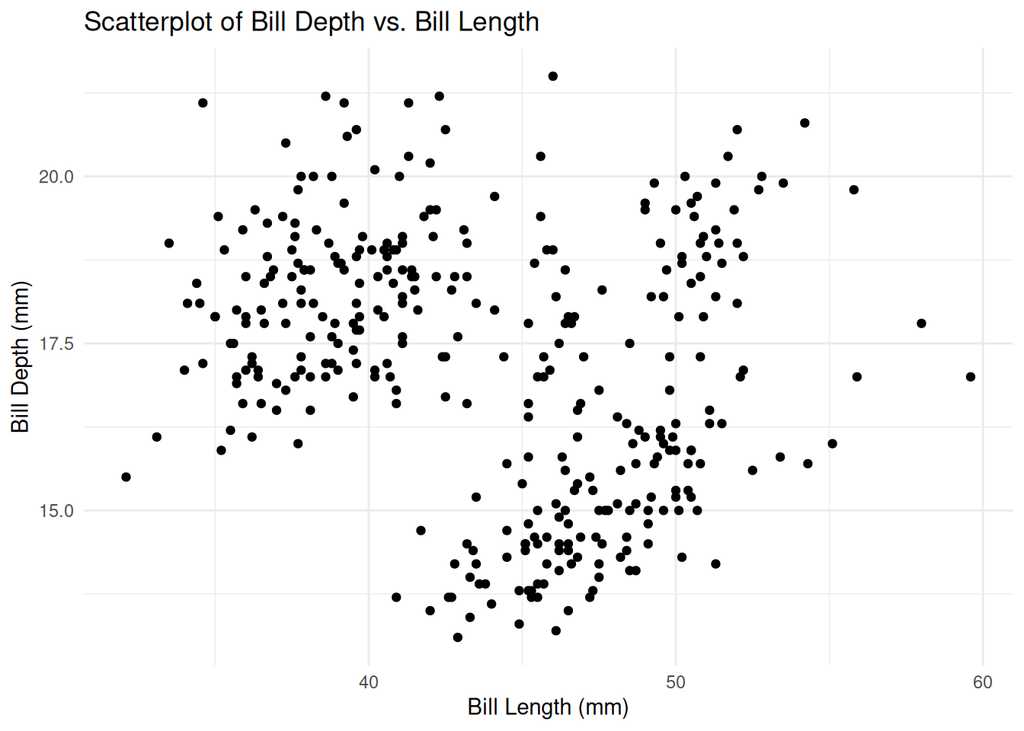

```r
ggplot(data = penguins, aes(x = bill_length_mm, y = bill_depth_mm)) +
  geom_point() +
  labs(
    title = "Scatterplot of Bill Depth vs. Bill Length",
    x = "Bill Length (mm)",
    y = "Bill Depth (mm)"
  ) +
  theme_minimal()
```

### 4.

Species is a categorical variable and bill depth is numeric. Scatterplots are ideal for two continuous variable, so plotting a categorical variable on one axis will stack points vertically or horizontally would not be ideal. Using geom_boxplot() will help show the distribution of a numeric variable across categories.

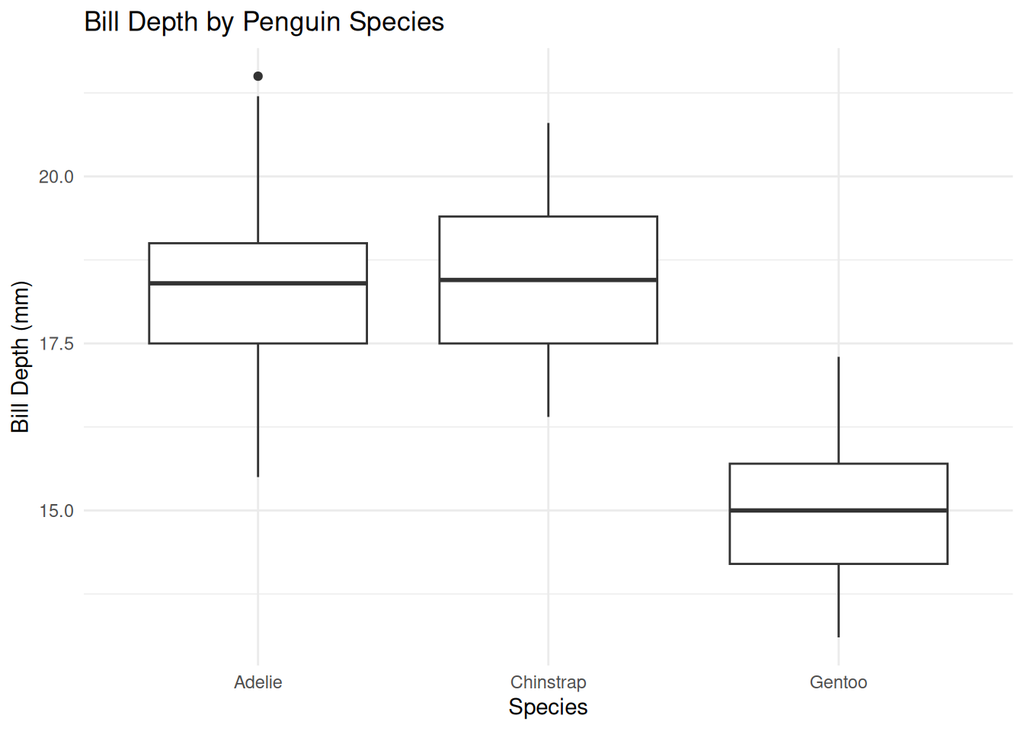

```r
ggplot(penguins, aes(x = species, y = bill_depth_mm)) +
  geom_boxplot() +
  labs(title = "Bill Depth by Penguin Species", x = "Species", y = "Bill Depth (mm)") +
  theme_minimal()
```

### 5.

That code gives an error because geom_point() needs to know which variables to plot on the x and y axes, and none are specified.

To fix it, I will tell geom_point() which varibales to use. I will plot bill length vs. bill depth.

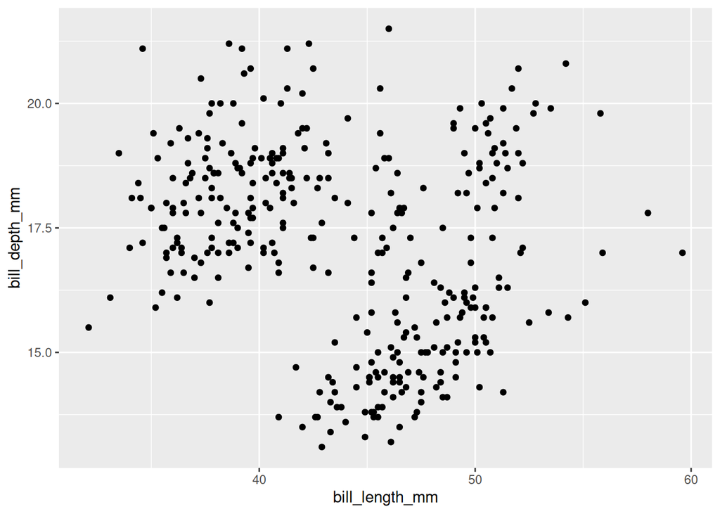

```r
ggplot(data = penguins, aes(x = bill_length_mm, y = bill_depth_mm)) +
  geom_point()
```

### 6.

The na.rm arguement in geom_point() controls whether missing values should be removed automatically before plotting. The default is na.rm = FALSE, which will give an error when encountering missing values.

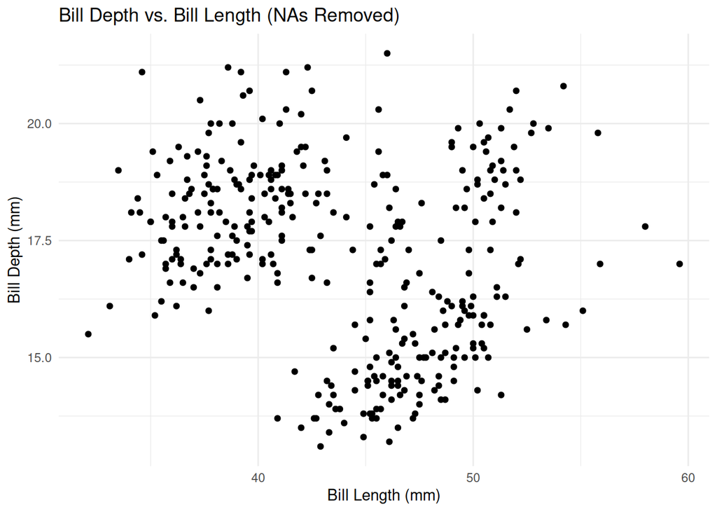

```r
ggplot(data = penguins, aes(x = bill_length_mm, y = bill_depth_mm)) +
  geom_point(na.rm = TRUE) +
  labs(
    title = "Bill Depth vs. Bill Length (NAs Removed)",
    x = "Bill Length (mm)",
    y = "Bill Depth (mm)"
  ) +
  theme_minimal()
```

### 7.

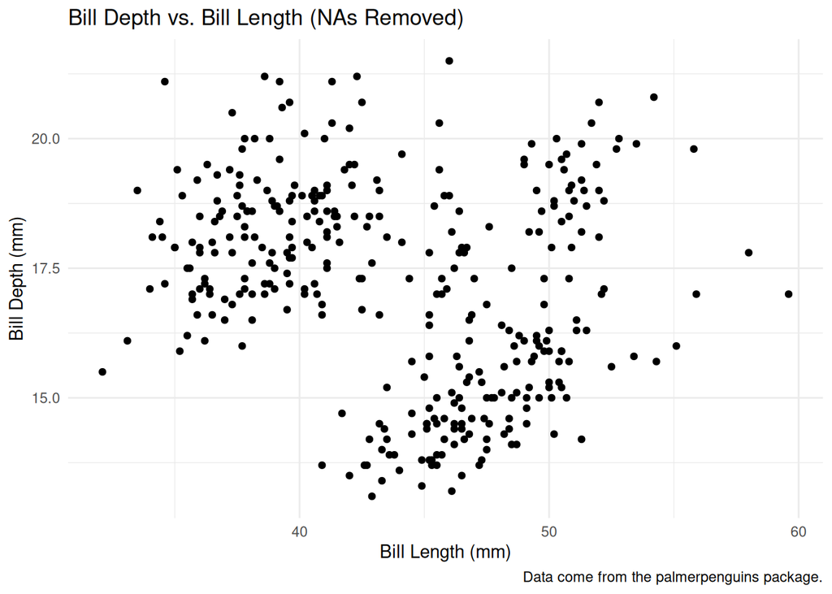

```r
ggplot(data = penguins, aes(x = bill_length_mm, y = bill_depth_mm)) +
  geom_point(na.rm = TRUE) +
  labs(
    title = "Bill Depth vs. Bill Length (NAs Removed)",
    x = "Bill Length (mm)",
    y = "Bill Depth (mm)",
    caption = "Data come from the palmerpenguins package."
  ) +
  theme_minimal()
```

### 8.

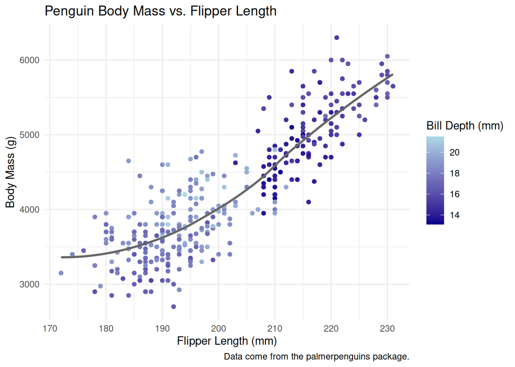

```r
ggplot(data = penguins, aes(x = flipper_length_mm, y = body_mass_g)) +
  geom_point(aes(color = bill_depth_mm), na.rm = TRUE) +
  scale_color_gradient(low = "darkblue", high = "lightblue") +
  geom_smooth(method = "loess", se = FALSE, color = "gray40", na.rm = TRUE) +
  labs(
    title = "Penguin Body Mass vs. Flipper Length",
    x = "Flipper Length (mm)",
    y = "Body Mass (g)",
    color = "Bill Depth (mm)",
    caption = "Data come from the palmerpenguins package."
  ) +
  theme_minimal()
```

### 9.

Prediction: Points will be colored by island with three separate trend lines for each island.

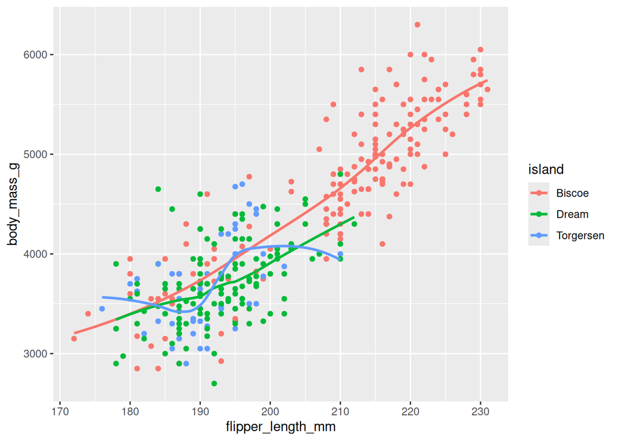

```r
ggplot(
  data = penguins,
  mapping = aes(x = flipper_length_mm, y = body_mass_g, color = island)
) +
  geom_point() +
  geom_smooth(se = FALSE)
```

### 10.

The two graphs will look the same because both use the same data and map the same aesthetics to x and y. The only difference is that one sets the mappings globally in ggplot(), while the other sets them locally in each geom; functionally, they produce identical output.

# Example 1.3

```r
penguins |>
  ggplot(aes(x = flipper_length_mm, y = body_mass_g)) +
  geom_point()
```

[output not shown]

# Example 1.4.1

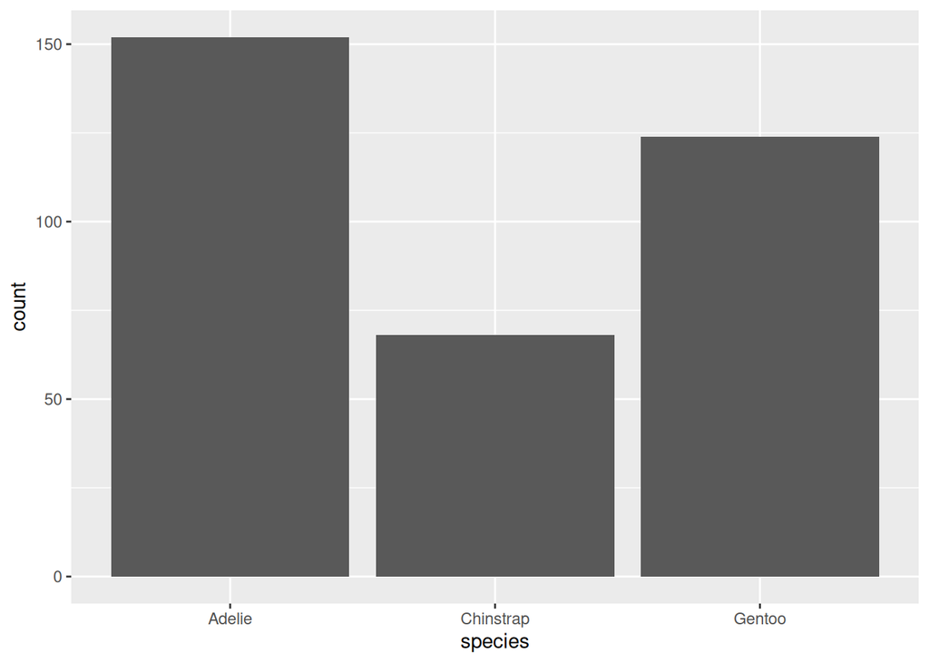

```r
ggplot(penguins, aes(x = species)) +
  geom_bar()
```

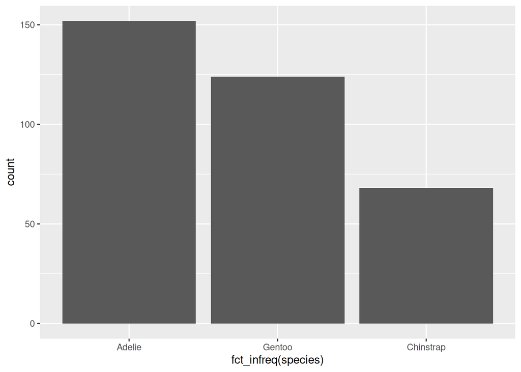

```r
ggplot(penguins, aes(x = fct_infreq(species))) +
  geom_bar()
```

# Example 1.4.2

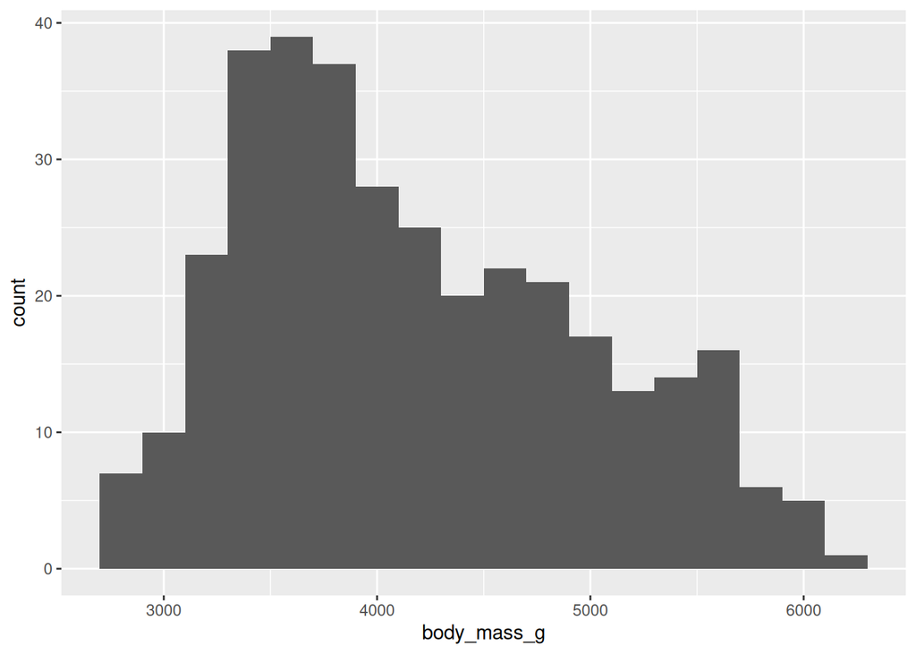

```r
ggplot(penguins, aes(x = body_mass_g)) +
  geom_histogram(binwidth = 200)
```

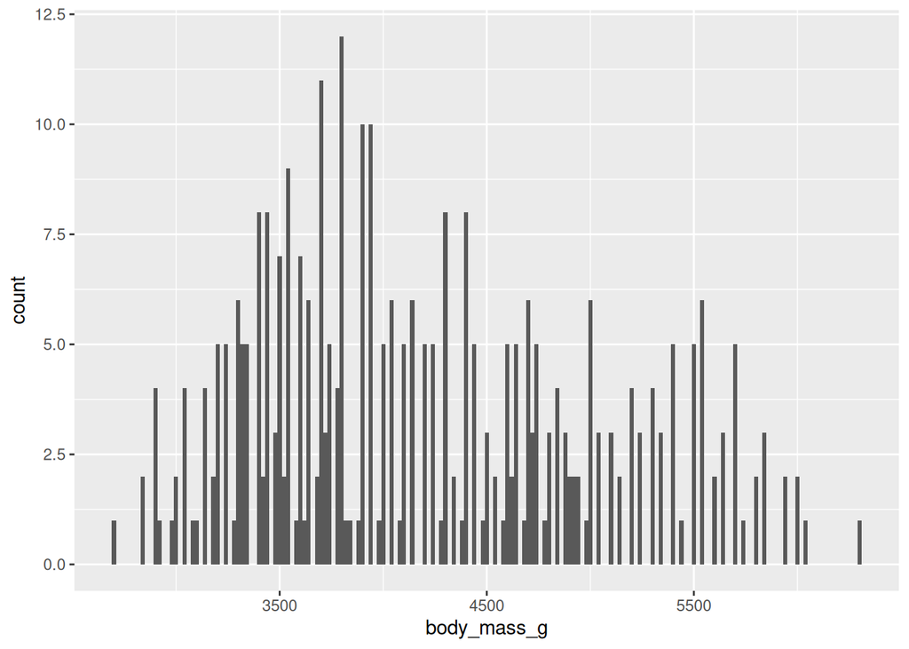

```r
ggplot(penguins, aes(x = body_mass_g)) +
  geom_histogram(binwidth = 20)
```

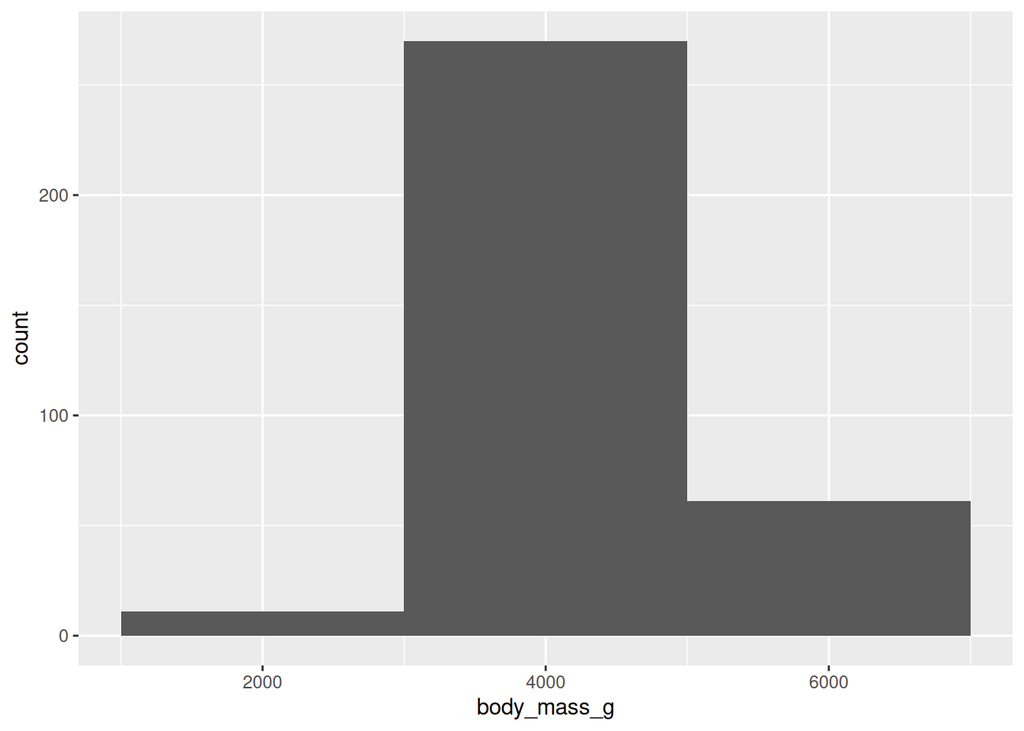

```r
ggplot(penguins, aes(x = body_mass_g)) +
  geom_histogram(binwidth = 2000)
```

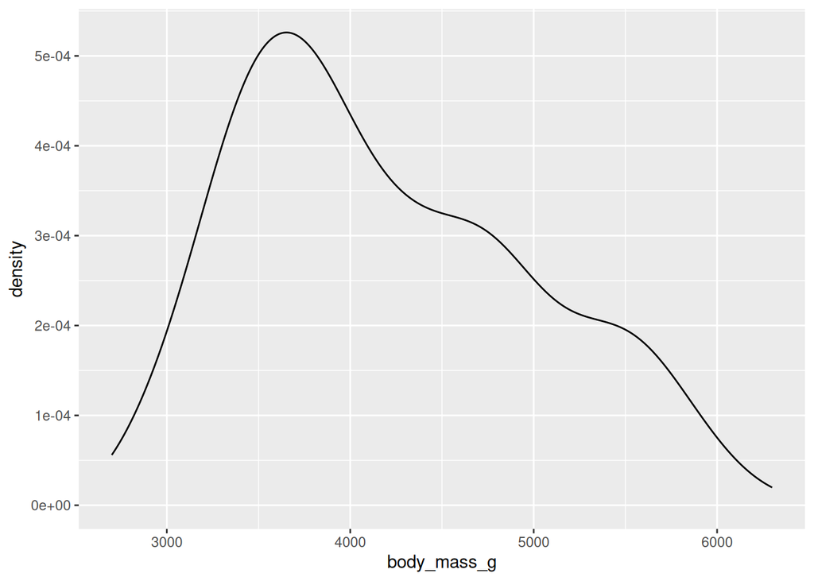

```r
ggplot(penguins, aes(x = body_mass_g)) +
  geom_density()
```

## Exercise 1.4.3

### 1.

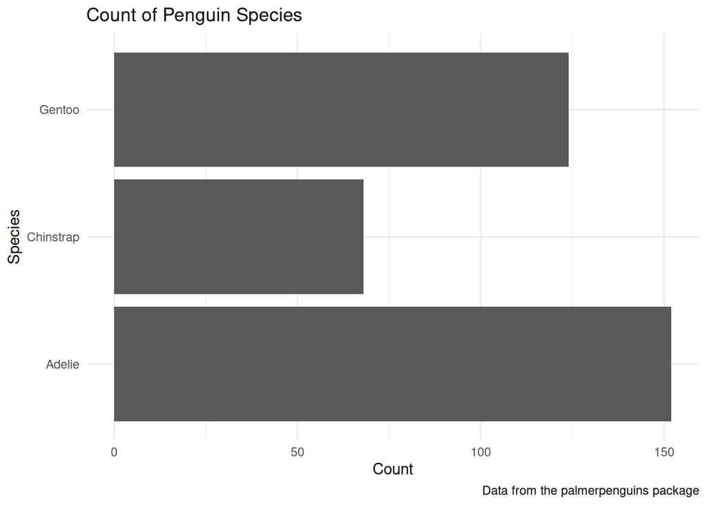

```r
ggplot(data = penguins, aes(y = species)) +
  geom_bar() +
  labs(
    title = "Count of Penguin Species",
    y = "Species",
    x = "Count",
    caption = "Data from the palmerpenguins package"
  ) +
  theme_minimal()
```

When species is assigned to the y-axis in a bar plot, the bars are drawn horizontally instead of vertically, which changes the orientation of the visual comparison.

### 2.

These two bar plots differ in how the color is applied to the bars. In the first plot, using color = “red” changes only the outline of each bar to red, leaving the interior of the bars in the default gray. The second plot uses fill = “red”, which changes the entire interior of the bars to red while keeping the outline unchanged. For bar plots, the fill aesthetic is generally more useful when you want to change the main color of the bars themselves, as it directly affects the visual emphasis and clarity of the chart. The color aesthetic is better suited for customizing the borders, which is less commonly used in basic bar chart design.

### 3.

The bins argument in geom_histogram() controls how many intervals (or “bins”) the data is divided into along the x-axis. Each bin represents a range of values, and the height of the bar shows how many observations fall within that range. By default, ggplot2 automatically selects a bin count based on the data, but you can manually adjust it to make the histogram more or less granular.

### 4.

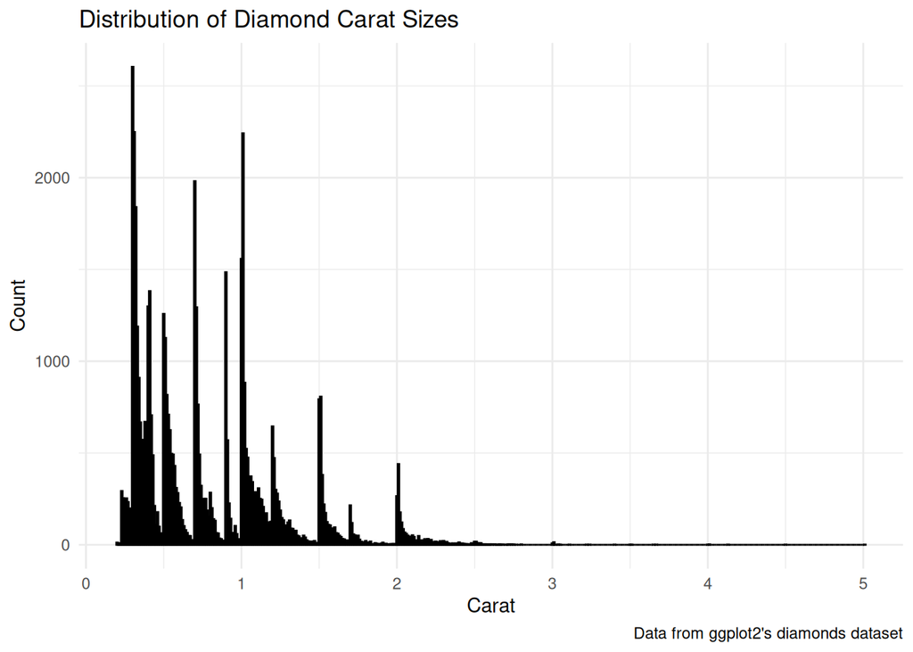

```r
ggplot(diamonds, aes(x = carat)) +
  geom_histogram(binwidth = 0.01, fill = "steelblue", color = "black") +
  labs(
    title = "Distribution of Diamond Carat Sizes",
    x = "Carat",
    y = "Count",
    caption = "Data from ggplot2's diamonds dataset"
  ) +
  theme_minimal()
```

Bandwidth = 0.01 is the most revealing and uncovers the clustering of diamond sizes and its patterns.

# Example 1.5.1

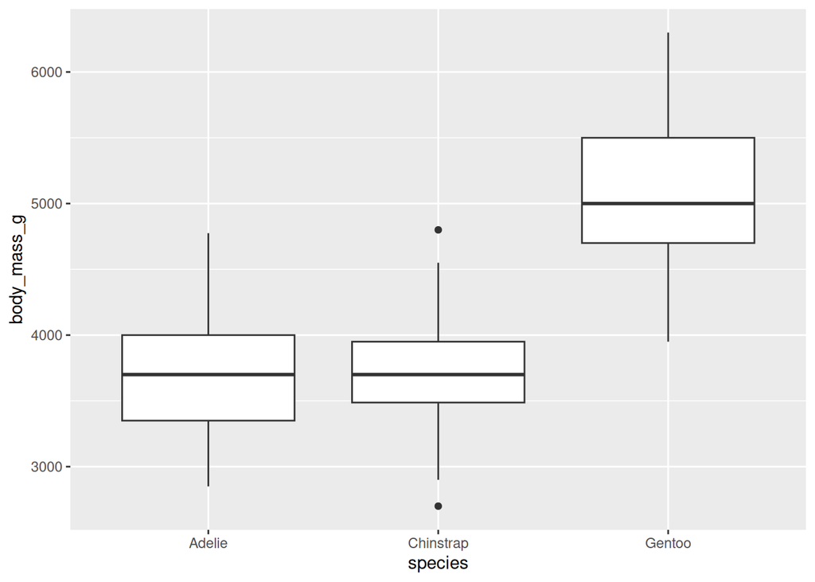

```r
ggplot(penguins, aes(x = species, y = body_mass_g)) +
  geom_boxplot()
```

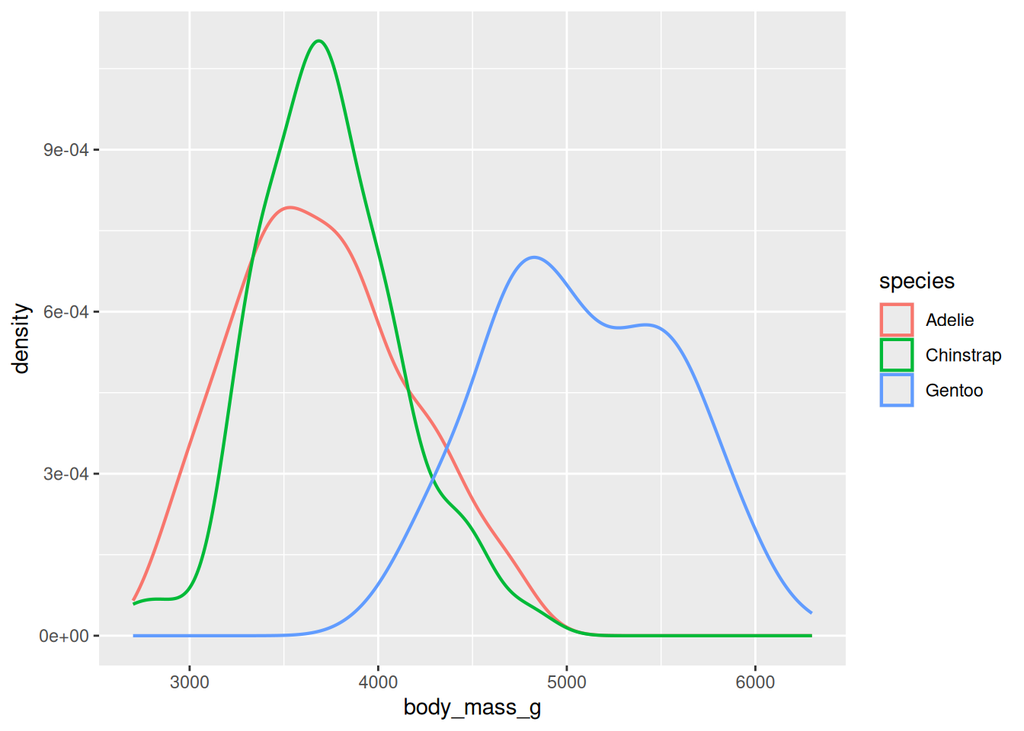

```r
ggplot(penguins, aes(x = body_mass_g, color = species)) +
  geom_density(linewidth = 0.75)
```

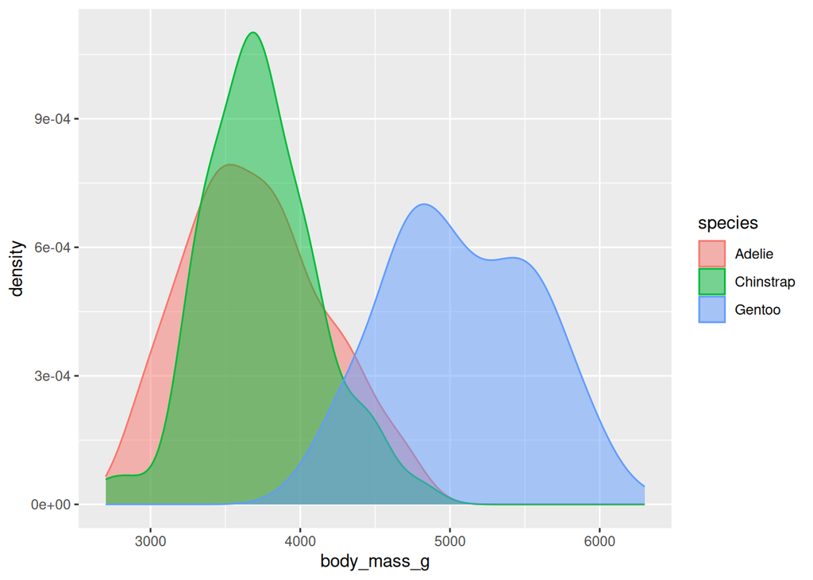

```r
ggplot(penguins, aes(x = body_mass_g, color = species, fill = species)) +
  geom_density(alpha = 0.5)
```

# Example 1.5.2

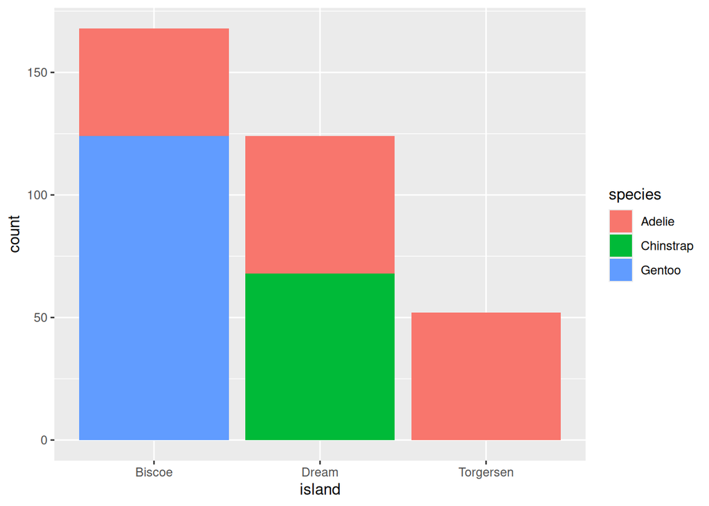

```r
ggplot(penguins, aes(x = island, fill = species)) +
  geom_bar()
```

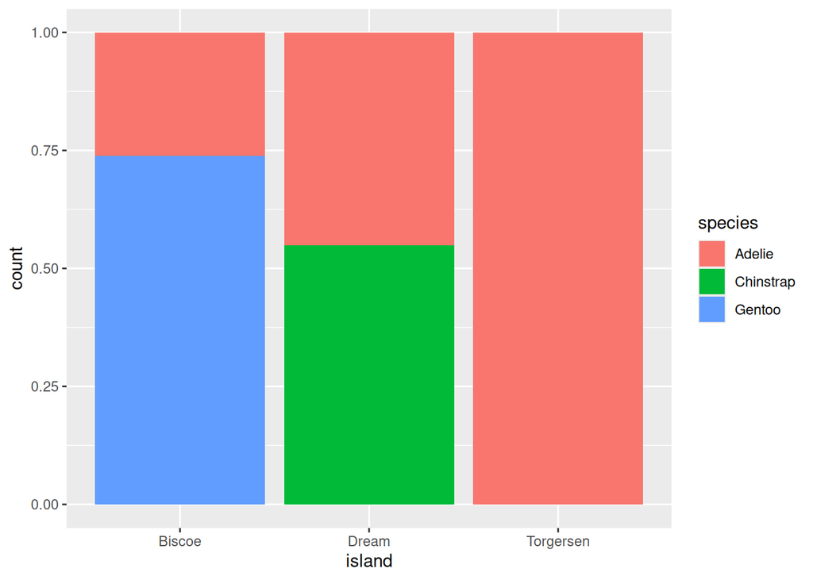

```r
ggplot(penguins, aes(x = island, fill = species)) +
  geom_bar(position = "fill")
```

# Example 1.5.3

```r
ggplot(penguins, aes(x = flipper_length_mm, y = body_mass_g)) +
  geom_point()
```

[output not shown]

# Example 1.5.4

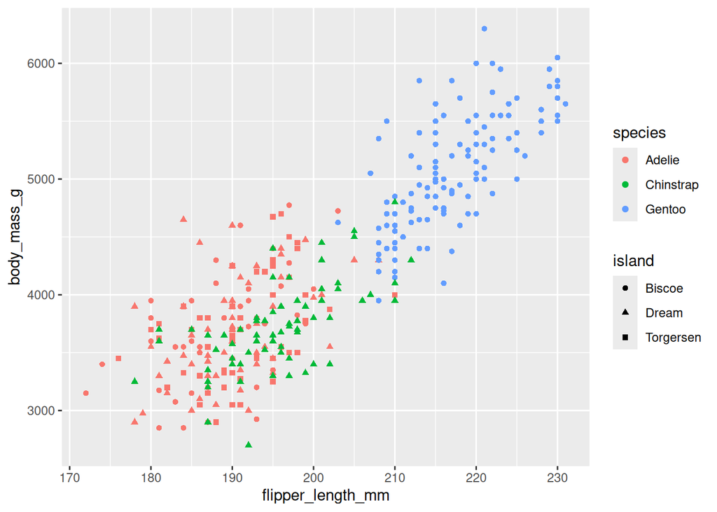

```r
ggplot(penguins, aes(x = flipper_length_mm, y = body_mass_g)) +
  geom_point(aes(color = species, shape = island))
```

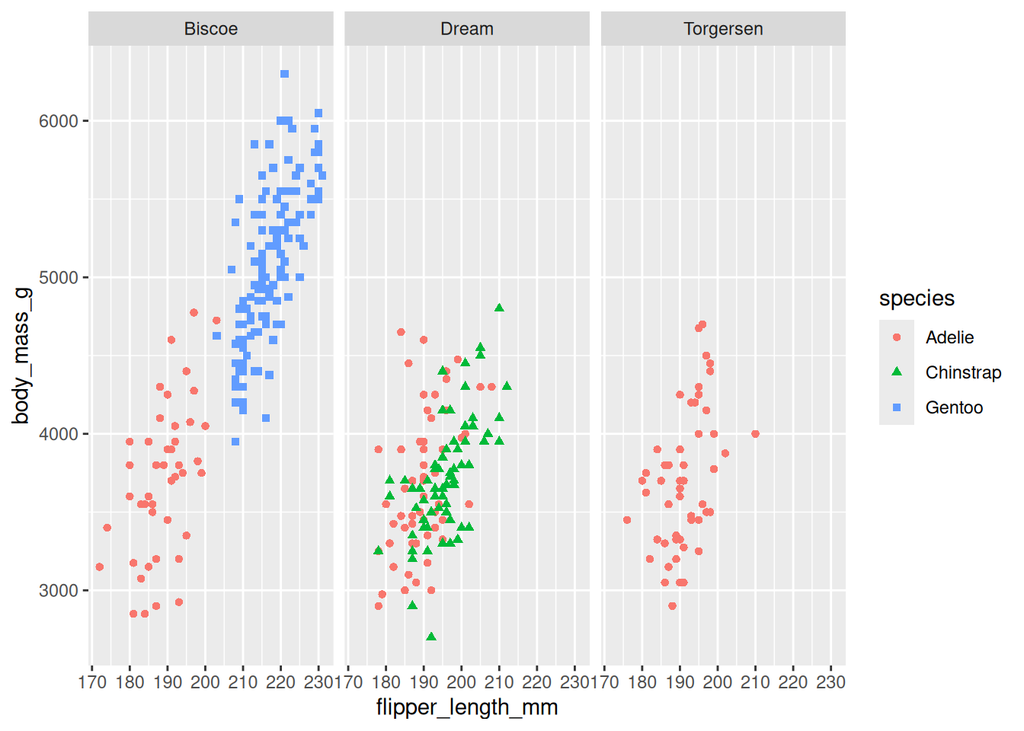

```r
ggplot(penguins, aes(x = flipper_length_mm, y = body_mass_g)) +
  geom_point(aes(color = species, shape = species)) +
  facet_wrap(~island)
```

## Exercise 1.5.5

### 1.

Numerical Variables: engine displacement (liters), year of manufacture, city miles per gallon, highway miles per gallon

Categorical Variables: car manufacturer, specific model name, type of transmission, drive type, fuel type, car class

We can see this using str(mpg) and glimpse(mpg)

```r
str(mpg)
```

```
tibble [234 × 11] (S3: tbl_df/tbl/data.frame)
 $ manufacturer: chr [1:234] "audi" "audi" "audi" "audi" ...
 $ model       : chr [1:234] "a4" "a4" "a4" "a4" ...
 $ displ       : num [1:234] 1.8 1.8 2 2 2.8 2.8 3.1 1.8 1.8 2 ...
 $ year        : int [1:234] 1999 1999 2008 2008 1999 1999 2008 1999 1999 2008 ...
 $ cyl         : int [1:234] 4 4 4 4 6 6 6 4 4 4 ...
 $ trans       : chr [1:234] "auto(l5)" "manual(m5)" "manual(m6)" "auto(av)" ...
 $ drv         : chr [1:234] "f" "f" "f" "f" ...
 $ cty         : int [1:234] 18 21 20 21 16 18 18 18 16 20 ...
 $ hwy         : int [1:234] 29 29 31 30 26 26 27 26 25 28 ...
 $ fl          : chr [1:234] "p" "p" "p" "p" ...
 $ class       : chr [1:234] "compact" "compact" "compact" "compact" ...
```

```r
glimpse(mpg)
```

```
Rows: 234
Columns: 11
$ manufacturer <chr> "audi", "audi", "audi", "audi", "audi", "audi", "audi", "…
$ model        <chr> "a4", "a4", "a4", "a4", "a4", "a4", "a4", "a4 quattro", "…
$ displ        <dbl> 1.8, 1.8, 2.0, 2.0, 2.8, 2.8, 3.1, 1.8, 1.8, 2.0, 2.0, 2.…
$ year         <int> 1999, 1999, 2008, 2008, 1999, 1999, 2008, 1999, 1999, 200…
$ cyl          <int> 4, 4, 4, 4, 6, 6, 6, 4, 4, 4, 4, 6, 6, 6, 6, 6, 6, 8, 8, …
$ trans        <chr> "auto(l5)", "manual(m5)", "manual(m6)", "auto(av)", "auto…
$ drv          <chr> "f", "f", "f", "f", "f", "f", "f", "4", "4", "4", "4", "4…
$ cty          <int> 18, 21, 20, 21, 16, 18, 18, 18, 16, 20, 19, 15, 17, 17, 1…
$ hwy          <int> 29, 29, 31, 30, 26, 26, 27, 26, 25, 28, 27, 25, 25, 25, 2…
$ fl           <chr> "p", "p", "p", "p", "p", "p", "p", "p", "p", "p", "p", "p…
$ class        <chr> "compact", "compact", "compact", "compact", "compact", "c…
```

### 2.

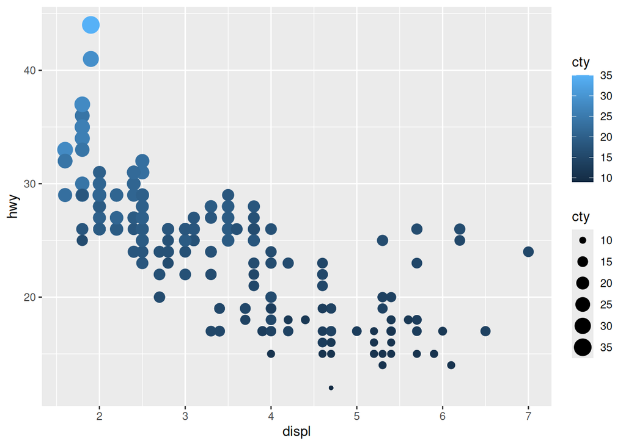

```r
ggplot(mpg, aes(x = displ, y = hwy, color = cty, size = cty)) +
  geom_point()
```

How do these aesthetics behave differently for categorical vs. numerical variables?

Color and size work well with numerical variables, while shape and fill are best for categorical ones.

### 3.

In the scatterplot of hwy vs. displ , what happens if you map a third variable to linewidth?

Mapping a third variable to linewidth in a scatterplot of hwy vs. displ doesn’t behave as expected because linewidth is primarily used to control the thickness of lines, not points. When mapping a variable like cty (city mpg) to linewidth in geom_point(), it won’t have any visible effect. However, linewidth does work in geoms like geom_line() or geom_smooth(), where the thickness of the line can reflect a numerical variable.

### 4.

Mapping the same variable to multiple aesthetics can reinforce its importance, but it’s most effective when the aesthetics complement each other and the variable type matches their intended use.

### 5.

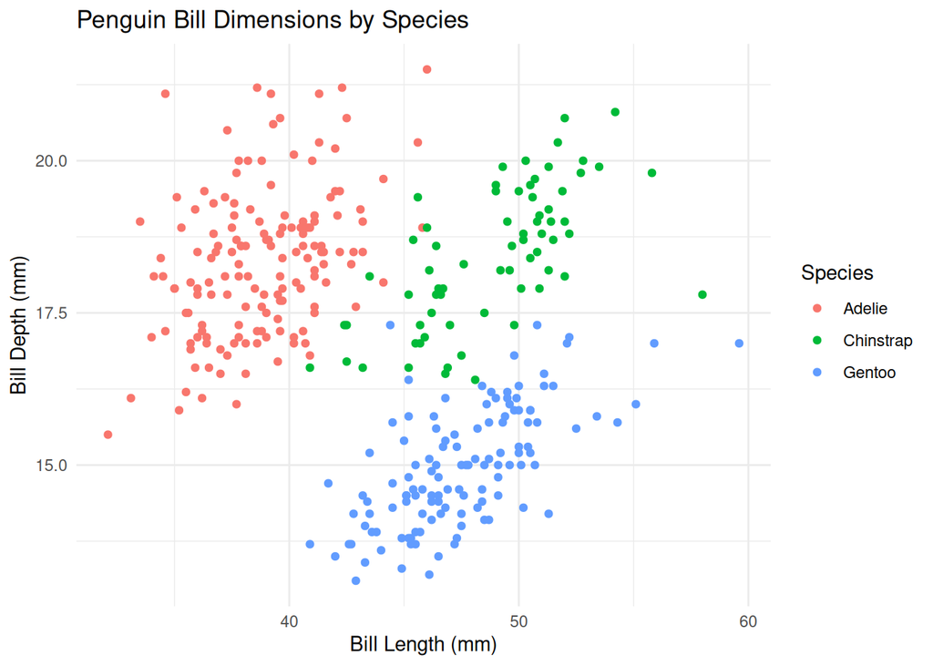

```r
ggplot(penguins, aes(x = bill_length_mm, y = bill_depth_mm, color = species)) +
  geom_point(na.rm = TRUE) +
  labs(
    title = "Penguin Bill Dimensions by Species",
    x = "Bill Length (mm)",
    y = "Bill Depth (mm)",
    color = "Species"
  ) +
  theme_minimal()
```

Coloring reveals inter-species differences in a shared space whole faceting isolates each species to show intra-species variation more clearly.

### 6.

This code yields two separate legends because ggplot2 treats color and shape as distinct aesthetics, even though they’re both mapped to the same variable. By default, it generates a separate legend for each aesthetic unless explicitly told to combine them.

To fix this and combine the legends into one unified guide, you can use the guides() function with guide = “legend” for both aesthetics.

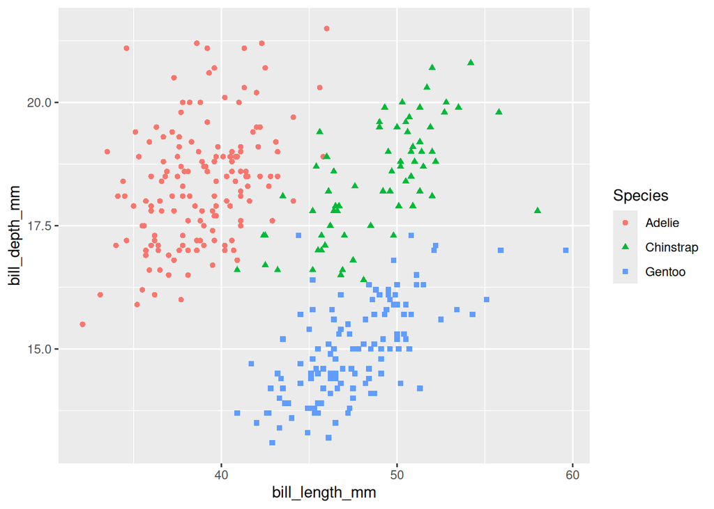

```r
ggplot(
  data = penguins,
  mapping = aes(
    x = bill_length_mm, y = bill_depth_mm,
    color = species, shape = species
  )
) +
  geom_point() +
  labs(color = "Species", shape = "Species") +
  guides(color = guide_legend(), shape = guide_legend())
```

### 7.

What is the species composition on each island?

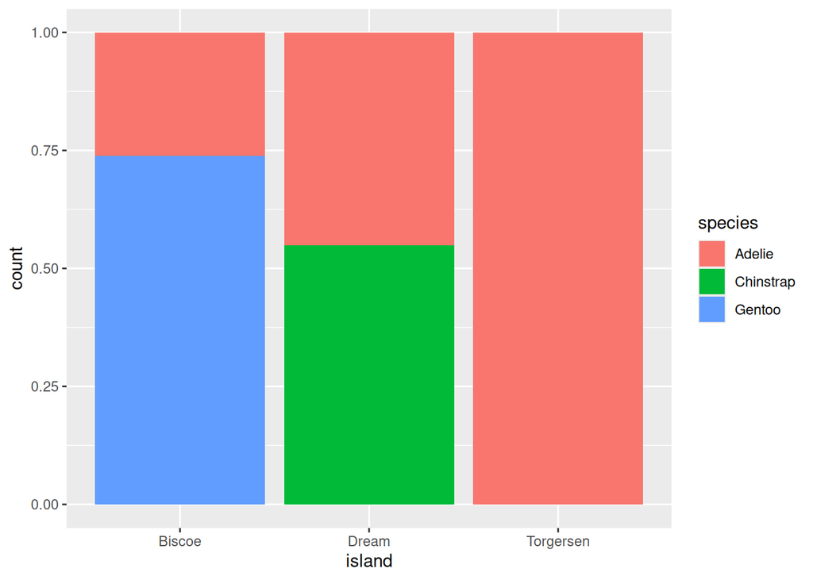

```r
library(ggplot2)
ggplot(penguins, aes(x = island, fill = species)) +
  geom_bar(position = "fill")
```

Where are individuals of each species found?

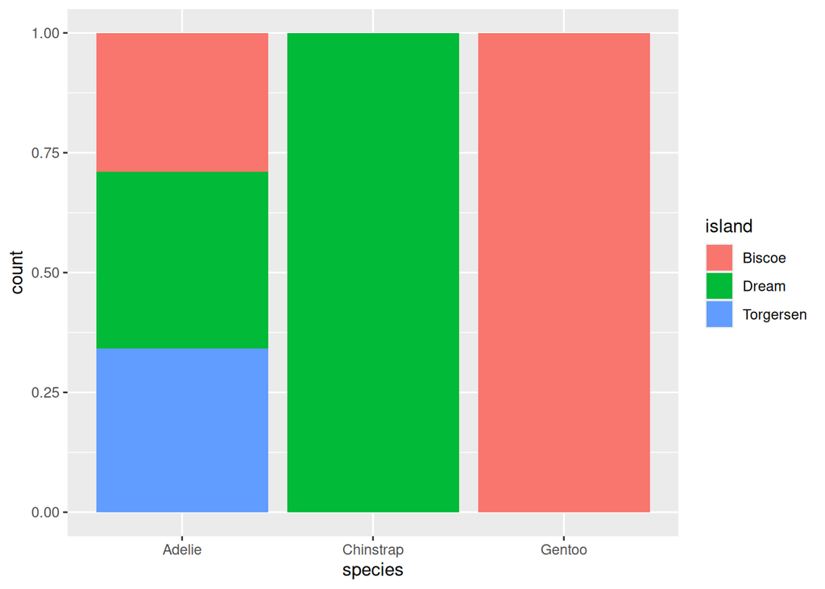

```r
ggplot(penguins, aes(x = species, fill = island)) +
  geom_bar(position = "fill")
```

# Example 1.6

```r
library(ggplot2)
library(palmerpenguins)

ggplot(penguins, aes(x = flipper_length_mm, y = body_mass_g)) +
  geom_point()
```

[output not shown]

```r
ggsave(filename = "penguin-plot.png")
```

## Exercise 1.6.1

### 1.

The second plot, the scatterplot of cty vs hwy is the one saved as mpg-plot.png because in R, when you run multiple ggplot()calls without assigning them to variables, only the last plot remains active in memory.

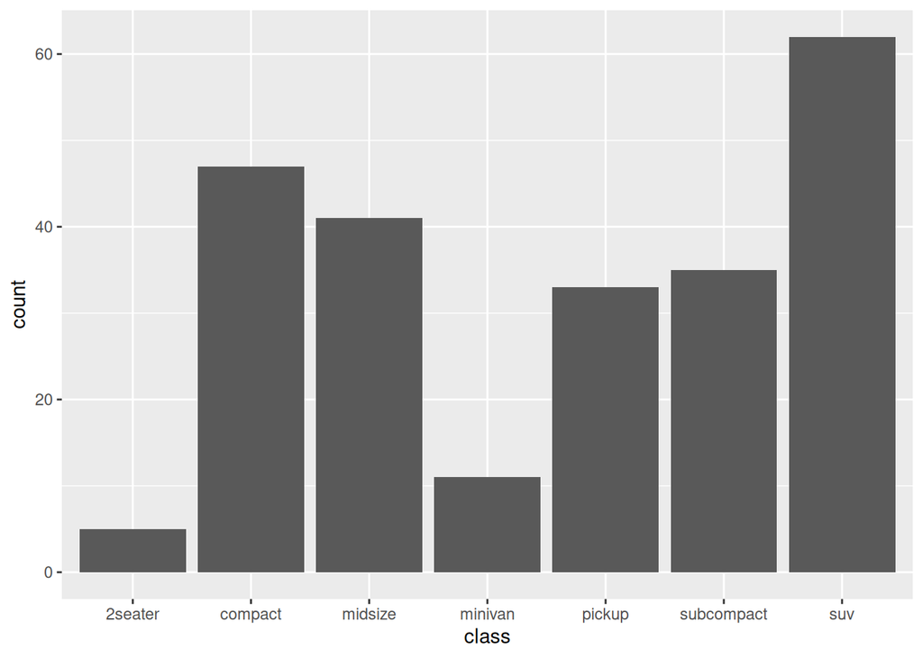

```r
ggplot(mpg, aes(x = class)) +
  geom_bar()
```

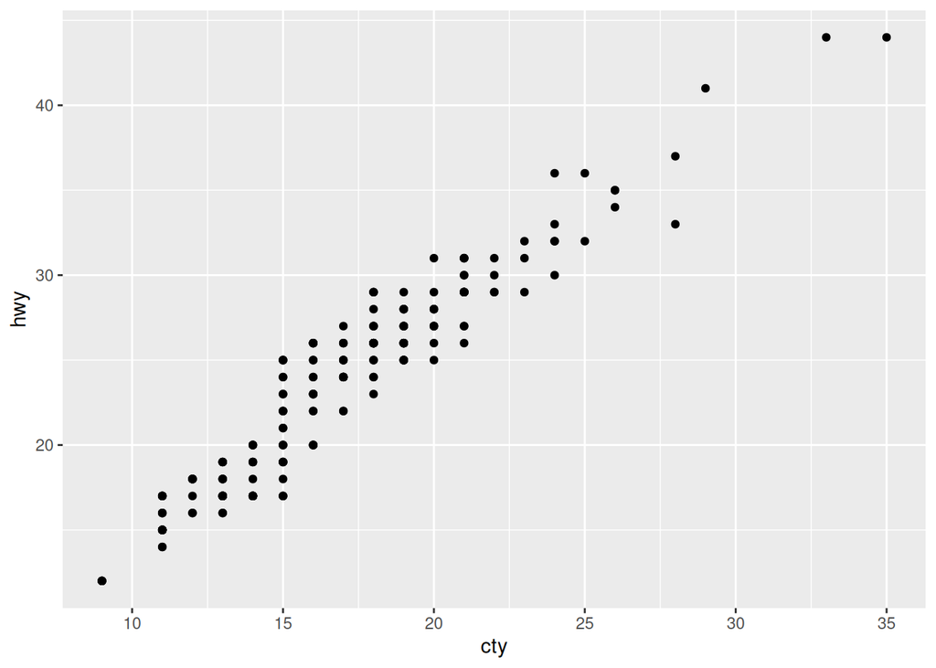

```r
ggplot(mpg, aes(x = cty, y = hwy)) +
  geom_point()
```

```r
ggsave("mpg-plot.png")
```

### 2.

To save the plot as a PDF instead of a PNG, you need to change the file extension in the filename argument of ggsave(). You can check he supported formats by running ?ggsave.